# Scripts to find correlation coefficients

## Example of correlation test where we have to use Spearman’s rank r<sub>sp</sub>

**Question**: Is WEMWBS score correlated with nep score?

### Load packages

```r
library(tidyverse)
library(here)
library(cowplot)
```

### Load data

We choose the marine wellness data set - where the data are ordinal data

```r
filepath <- here("data","marine_wellness.csv")
wellness <- read_csv(filepath)
glimpse(wellness)
```

```
## Rows: 288
## Columns: 3
## $ id     <dbl> 1, 5, 6, 7, 9, 10, 11, 14, 15, 17, 18, 19, 20, 21, 22, 23, 24, …
## $ WEMWBS <dbl> 48, 38, 40, 54, 54, 39, 51, 51, 54, 52, 46, 51, 35, 53, 55, 37,…
## $ nep    <dbl> 52, 47, 49, 45, 51, 55, 47, 47, 51, 53, 54, 52, 49, 50, 49, 54,…
```

We have wellness scores for 288 individuals according to two scales - WEMWBS and nep

### Plot the data - WEMWBS score vs nep score

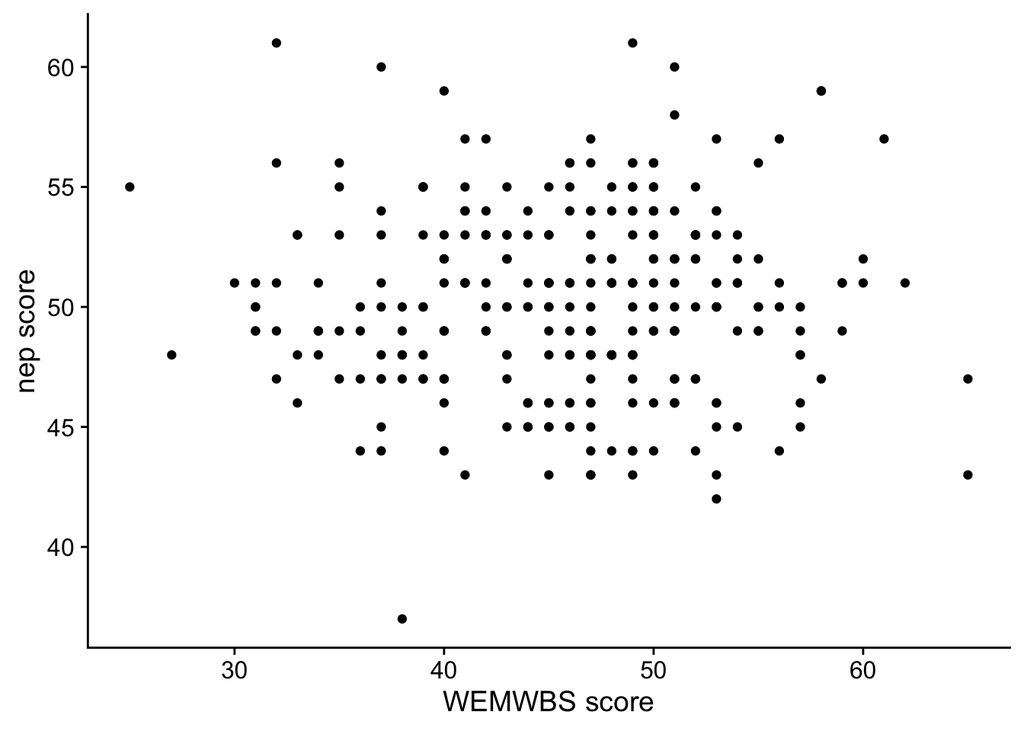

```r
wellness %>%
  ggplot(aes(x = WEMWBS, y = nep)) + # what we want to plot
  geom_point() + # what kind of plot
  labs(x = "WEMWBS score",
       y = "nep score") + # axis labels
  theme_cowplot() # give the plot a nice 'look'
```

Does it look as though the relationship between the two scores is monotonic?

### Test for correlation

```r
cor.test(wellness$WEMWBS,wellness$nep, method = "spearman", exact=FALSE)
```

```
##
##  Spearman's rank correlation rho
##
## data:  wellness$WEMWBS and wellness$nep
## S = 3858584, p-value = 0.6025
## alternative hypothesis: true rho is not equal to 0
## sample estimates:
##        rho
## 0.03081439
```

#### Interpret the output

- What is r<sub>sp</sub>?
- Is p < 0.05?
- Is r significantly different from zero?